# Week5

### 11.6.3

It fits the differential equation:

$$y(t) = t^{\frac32}\implies y'(t) = \frac32 t^{\frac12} = \frac32y^{\frac13}$$

And it fits the initial value:

$$y(0) = 0^{\frac32} = 0$$

Here's some code to apply Euler's method:

```python
# NOTE: All code is written in Python with the modules matplotlib and numpy installed.
# You can install them with the following terminal commands:
#     pip install matplotlib
#     pip install numpy

def yp(y):
    return 3/2 * y**(1/3)
h = 1e-3
y = t = 0
end = 9

while t < end:
    y += h*yp(y)
    t += h

print(f"y({end}) = {y}")
```

```
y(9) = 0.0
```

It fails because $y'$ is always equal to $0$ when $y$ is equal to $0$, so $y$ just stays zero. In fact, a second solution to the initial value problem is $y(t) = 0$, so Euler's method in this case is just giving the values for this other solution.

If you slightly perturb the initial value so that $y = 10^{-5}$ instead of $0$ at the start, then it fits very closely with the function given:

```python
def yp(y):
    return 3/2 * y**(1/3)
h = 1e-5
t = 0
y = 1e-5
end = 9

while t < end:
    y += h*yp(y)
    t += h

print(f"y({t}) = {y}")
print(f"(Correct value: {t**(3/2)})")
```

```
y(9.000009999828448) = 27.002022653914178
(Correct value: 27.000044999240515)
```

### 11.6.5

We start with

$$R_0 = 2, F_0 = 1$$

**Euler's method**

After one step, we have

$$R_{0.1} = R_0 + 0.1(2-F_0)(R_0) = 2.2$$$$F_{0.1} = F_0 + 0.1(R_0-2)F_0 = 1$$

**Midpoint method**

The midpoint is

$$R_{0.05} = 2 + 0.05(2-1)(2) = 2.1$$$$F_{0.05} = 1 + 0.05(2-2)(1) = 1$$

So after one step we have

$$R_{0.1} = R_0 + 0.1(2-F_{0.05})R_{0.05} = 2.21$$$$F_{0.1} = F_0 + 0.1(2-R_{0.05})F_{0.05} = 0.99$$

**Heun's method**

Using the Euler's method we come up with

$$\tilde{R}_{0.1} = R_0 + 0.1(2-F_0)(R_0) = 2.2$$$$\tilde{F}_{0.1} = F_0 + 0.1(R_0-2)F_0 = 1$$

So after one step we have

$$R_{0.1} = R_0 + 0.05[(2-F_0)R_0 + (2-\tilde{F}_{0.1})\tilde{R}_{0.1}] = 2 + 0.05[2 + 2.2] = 2.21$$$$F_{0.1} = F_0 + 0.05[(R_0-2)F_0 + (\tilde{R}_{0.1}-2)\tilde{F}_{0.1}] = 1 + 0.05[0 - 0.2] = 0.99$$

### 11.6.6

First to calculate the $k$-values. We have

$$\begin{align*} k_1 &= \lambda y\\ k_2 &= \lambda (y + \frac{h}{2}k_1) = \left(\lambda + \frac{h\lambda^2}{2}\right)y\\ k_3 &= \lambda (y + \frac{h}{2}k_2) = \left(\lambda + \frac{h\lambda^2}{2} + \frac{h^2\lambda^3}{4}\right)y\\ k_4 &= \lambda (y + hk_3) = \left(\lambda + h\lambda^2 + \frac{h^2\lambda^3}{2} + \frac{h^3\lambda^4}{4}\right)y \end{align*}$$

Then,

$$ \begin{align*} y_{k+1} &= y_k + \frac16h(k_1 + 2k_2 + 2k_3 + k_4)\\ &= \left[1 + \frac{h}{6}\left(\lambda + 2\left(\lambda + \frac{h\lambda^2}{2}\right) + 2\left(\lambda + \frac{h\lambda^2}{2} + \frac{h^2\lambda^3}{4}\right) + \left(\lambda + h\lambda^2 + \frac{h^2\lambda^3}{2} + \frac{h^3\lambda^4}{4}\right)\right)\right]y_k\\ &= \left[1 + \frac{h}{6}\left(6\lambda + 3h\lambda^2 + h^2\lambda^3 + \frac{h^3\lambda^4}{4}\right)\right]y_k\\ &= \left[1 + h\lambda + \frac{(h\lambda)^2}{2} + \frac{(h\lambda)^3}{6} + \frac{(h\lambda)^4}{24}\right]y_k \end{align*} $$

The local truncation error is $$y(t_{k+1}) - y_{k+1}$$ where $y$ is the exact solution of the initial value problem $$y' = \lambda y; y(t_k) = y_k$$

Notice that $y^{(n)} = \lambda^n y$, so the Taylor series of $y$ about $t_k$ is $$y(t) = y_k + (\lambda y_k)(t-t_k) + (\lambda^2 y_k)\frac{(t-t_{k})^2}{2!} + \cdots$$

Then, $$\begin{align*} y(t_{k+1}) &= y_k + (\lambda y_k)h + (\lambda^2 y_k)\frac{h^2}{2!} + \cdots\\ &= [1 + h\lambda + \frac{(h\lambda)^2}{2} + \frac{(h\lambda)^3}{6} + \cdots]y_k \end{align*} $$

Therefore the local truncation error is

$$y(t_{k+1}) - y_{k+1} = \left[\frac{(h\lambda)^5}{5!} + \frac{(h\lambda)^6}{6!} + \frac{(h\lambda)^7}{7!} + \cdots\right]y_k = O(h^5)y_k$$

and so it is order $5-1=4$.

### 11.6.7

We are under the assumption that $f$ is Lipschitz. First we will show that each $k_i$ is Lipschitz in $y$. It suffices to prove that if $g$ and $h$ are two Lipschitz functions then $f\circ g$ is also Lipschitz. But this is obvious:

$$|g(h(a)) - g(h(b))| \le L_g|h(a) - h(b)|\le L_gL_h |a-b|$$

$k_1$ is just $f$, so it must be Lipschitz. Each $k_i$ ($2\le i\le 4$) is a function of the form

$$k_i = f(g_1(t, h), g_2(k_{i-1}))$$

where $g_2(y, k_{i-1})$ is linear combination of $y$ and $k_{i-1}$. As both $y$ and $k_{i-1}$ are Lipschitz in $y$, so is $g_2$. Finally, $g_1(t, h)$ is just a constant, so it can be ignored (you let $t$ range through all of $[0, n]$ and whichever value maximises the function $k_i$ is used for the boundary condition).

Putting this all together, we find that $k_i$ is Lipschitz if $k_{i-1}$ is, and because $k_1$ is Lipschitz all of $k_1, k_2, k_3,$ and $k_4$ are Lipschitz. Then,

$$\psi(t, y, h) = y + \frac16h(k_1+2k_2+2k_3+k_4)$$

is a linear combination of Lipschitz functions and so is Lipschitz itself. It was proven in the textbook that this was a sufficient condition to show that the Runge-Kutta method is *stable*.

### #5

(a)

From the Butcher tableau, we have $$y_{n+1} = y_n + \frac14\left[f(t_n, y_n) + 4b_2f(t_n+\frac23h, y_n+\beta hf(t_n, y_n))\right]$$

To be consistent we need $$\frac14[1 + 4b_2] = 1\implies b_2 = \frac34$$

To be stable we need $\beta = \frac23$

(b)

$$\begin{align*} k_1 &= f(t_n, y_n)\\ k_2 &= f(t_n+\frac23 h, y_n + \frac23 hk_1)\\ y_{n+1} &= y_n + \frac14h\left[f(t_n, y_n) + 3f\left(t_n+\frac23 h, y_n + \frac23 hk_1\right)\right] \end{align*}$$

(c)

The second derivative of $y$ is $$y'' = (y')' = \frac{df(t, y)}{dt} = \frac{\partial f(t, y)}{\partial t} + \frac{\partial f(t, y)}{\partial y}\frac{\partial y}{\partial t} = \frac{\partial f(t, y)}{\partial t} + \frac{\partial f(t, y)}{\partial y}f(t, y)$$

So the second order Taylor expansion of $y$ is $$y_{n+1} \approx y_n + f(t_n, y_n)h + \left(\frac{\partial f(t_n, y_n)}{\partial t} + \frac{\partial f(t_n, y_n)}{\partial y}f(t_n, y_n)\right)\frac{h^2}{2}$$

Now, in Ralston's method the second order Taylor expansion is

$$\begin{align*} y_{n+1}&\approx y_n + \frac14h\left[\left(f(t_n, y_n)\right) + 3\left(f(t_n, y_n) + \left(\frac{\partial f(t_n, y_n)}{\partial t} + \frac{\partial f(t_n, y_n)}{\partial y}f(t_n, y_n)\right)\frac{\left(\frac23h\right)^2}{2}\right)\right]\\ &= y_n + f(t_n, y_n)h + \left(\frac{\partial f(t_n, y_n)}{\partial t} + \frac{\partial f(t_n, y_n)}{\partial y}f(t_n, y_n)\right)\frac{h^2}{2} \end{align*}$$

which is the same. Therefore Ralston's method is second order accurate.

### #6

(a) First a correction: the last step should read

$$y_{n+1} = y_n + \frac12\left[\frac32 K_1 + \frac12 K_2\right]$$

instead of

$$y_{n+1} = y_n + \frac32 K_1 + \frac12 K_2$$

Oh wait, this wasn't a mistake in the problem, it's the reason the method doesn't work!

Now here's my code:

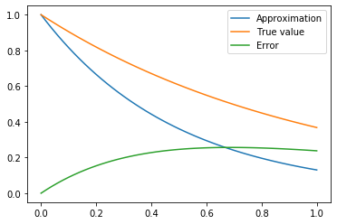

```python
import numpy as np
import matplotlib.pyplot as plt

h = 1/50

def f(y): # f doesn't depend on t
    return -y
def next_y(t, y):
    k1 = h*f(y)
    k2 = h*f(y+1/3*k1)
    return y + (3/2*k1 + 1/2*k2)

t, y = 0, 1
end = 1
ts = [t]
ys = [y]
while t < end:
    y = next_y(t, y)
    ys.append(y)
    t += h
    ts.append(t)

def true_y(t):
    return np.exp(np.negative(t))

plt.plot(ts, ys, label="Approximation")
plt.plot(ts, true_y(ts), label="True value")
plt.plot(ts, abs(np.subtract(true_y(ts), ys)), label="Error")
plt.legend()
```

(b)

The issue is the method isn't **consistent**. We have the local truncation error

$$\frac{y_{n+1}-y_n}{h} = \frac32f(t_n, y_n) + f(t_n+\frac12h, y_n+\frac13K_1)$$

But,

$$\lim_{h\to 0}\frac32f(t_n, y_n) + f(t_n+\frac12h, y_n+\frac13K_1) = 2f(t_n, y_n)$$

when it should be equal to $f(t_n, y_n)$. If we change the method slightly (as in my "correction" above) it works perfectly fine:

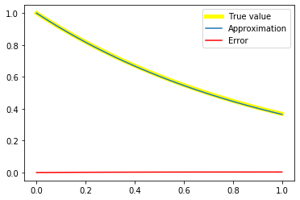

```python
h = 1/50

def f(y): # f doesn't depend on t
    return -y
def next_y(t, y):
    k1 = h*f(y)
    k2 = h*f(y+1/3*k1)
    return y + 0.5*(3/2*k1 + 1/2*k2)

t, y = 0, 1
end = 1
ts = [t]
ys = [y]
while t < end:
    y = next_y(t, y)
    ys.append(y)
    t += h
    ts.append(t)

def true_y(t):
    return np.exp(np.negative(t))

plt.plot(ts, true_y(ts), label="True value", linewidth=5, color="yellow")
plt.plot(ts, ys, label="Approximation")
plt.plot(ts, abs(np.subtract(true_y(ts), ys)), label="Error", color="red")
plt.legend()
```